# Lab2 Rmarkdown, data and visualization

# Working with functions in R and ploting them

In this econometrics class you start with the hypothesis that there is a linear causal relationship between to variables. Do not worry we will elaborate on these concepts more and more during the semester. But let’s look at how a linear relationship looks like A perfect linear relation betwen x and y follows the following form $y=a+bx$. Let’s look at the graph of this.

**A linear function**

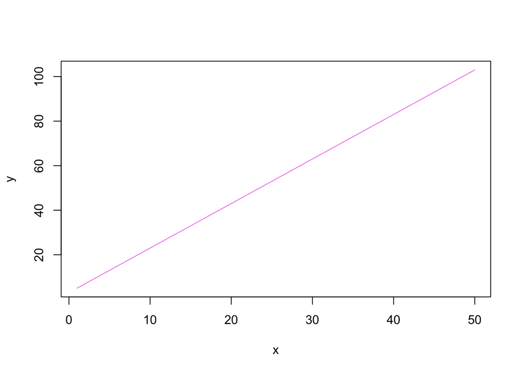

```r
library("ggplot2")
eq = function(x){3+2*x}
eq2= function(x){10+0.5*x}

curve(eq, from=1, to=50, xlab="x", ylab="y", col="violet")
```

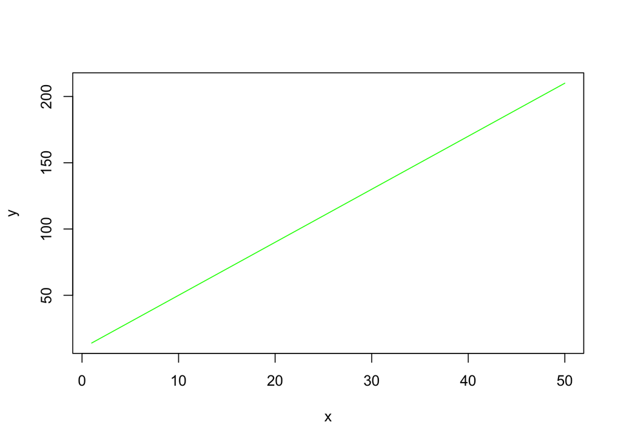

```r
curve(10+4*x, from=1, to=50, xlab="x", ylab="y", col="green")
```

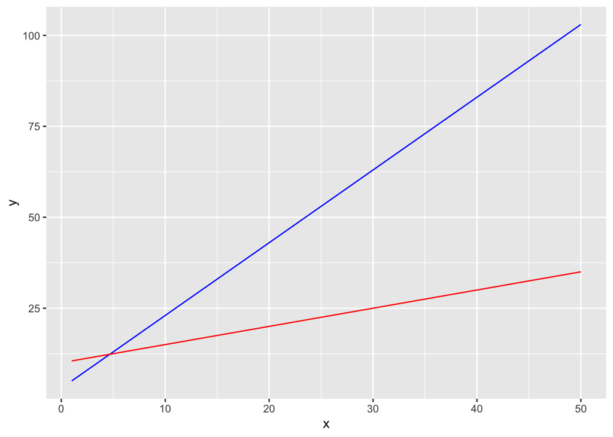

```r
ggplot(data.frame(x=c(1, 50)), aes(x=x)) +
  stat_function(fun=eq, geom="line", col=4) +
  stat_function(fun=eq2, geom="line", col=2) +
  xlab("x") + ylab("y")
```

**Log function**

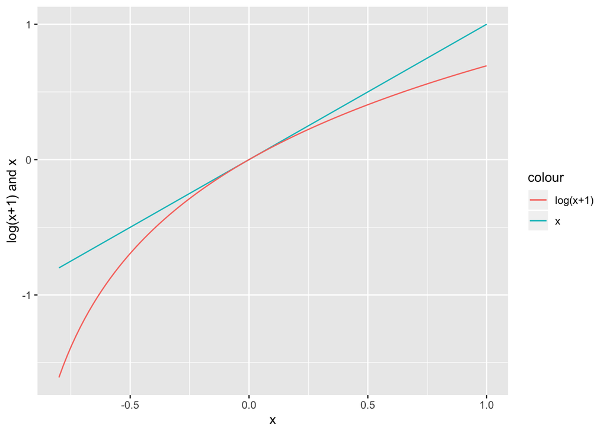

```r
ggplot(data.frame(x=c(-0.8,1)), aes(x)) +
  stat_function(fun=function(x)x, geom="line", aes(colour="x")) +
  stat_function(fun=function(x)log(x+1), geom="line", aes(colour="log(x+1)")) +ylab("log(x+1) and x" )
```

ECON320 R Programing Laboratory

Professor *Paloma Lopez de mesa Moyano*

*paloma.moyano@emory.edu*

Department of Economics

Emory University